# Quantitative Research Skills 2022, Hands-On Exercise 2

Factor Analysis

# Hands-On Exercise 2: Factor Analysis

We will start straight from the data set that you saved in the end of the **Hands-On-Exercise 1b** (or in the end of the **Assignment1**). In case you used a different name for the data, change it below:

```r
library(tidyverse)
USHSv2  <-  read_csv("USHSv2.csv")
USHSv2
```

```
## # A tibble: 3,110 x 100
##    fsd_id    k1    k2   bv1   bv3   bv6    k7  k8_1  k8_2  k8_3  k8_4  k9_1
##     <dbl> <dbl> <dbl> <dbl> <dbl> <dbl> <dbl> <dbl> <dbl> <dbl> <dbl> <dbl>
##  1      1    NA     1     1    23     0     1     4     4     4     5    NA
##  2      2     2     2     1    23     0     1     4     4     4     4     3
##  3      3     3     1     1    23     0     1     3     3     3     3     2
##  4      4     2     1     1    23     0     1     4     5     5     5     2
##  5      5     2     1     1    23     0     2     5     4     5     5     3
##  6      6    NA     2     1    24     0     1     4     3     3     3     2
##  7      7     2     2     1    24     0     1     3     2     1     3     2
##  8      8     1     2     1    24     0     1     4     4     4     4     1
##  9      9     2     2     1    24     0     1     4     4     4     4     1
## 10     10     3     2     1    24     0     1     3     3     5     3     3
## # … with 3,100 more rows, and 88 more variables: k9_2 <dbl>, k9_3 <dbl>,
## #   k9_4 <dbl>, k9_5 <dbl>, k9_6 <dbl>, k9_7 <dbl>, k9_8 <dbl>, k9_9 <dbl>,
## #   k9_10 <dbl>, k9_11 <dbl>, k9_12 <dbl>, k9_13 <dbl>, k9_14 <dbl>,
## #   k9_15 <dbl>, k9_16 <dbl>, k9_17 <dbl>, k9_18 <dbl>, k9_19 <dbl>,
## #   k9_20 <dbl>, k9_21 <dbl>, k9_22 <dbl>, k9_23 <dbl>, k9_24 <dbl>,
## #   k9_25 <dbl>, k9_26 <dbl>, k9_27 <dbl>, k9_28 <dbl>, k9_29 <dbl>,
## #   k9_30 <dbl>, k11a <dbl>, k11b <dbl>, k12a <dbl>, k12b <dbl>, k13 <dbl>,
## #   k14 <dbl>, k15 <dbl>, k16 <dbl>, k17 <dbl>, k18 <dbl>, k19 <dbl>,
## #   k20 <dbl>, k21_1 <dbl>, k21_2 <dbl>, k21_3 <dbl>, k21_4 <dbl>, k21_5 <dbl>,
## #   k21_6 <dbl>, k21_7 <dbl>, k21_8 <dbl>, k21_9 <dbl>, k22_1 <dbl>,
## #   k22_2 <dbl>, k22_3 <dbl>, k22_4 <dbl>, k22_5 <dbl>, k22_6 <dbl>,
## #   k22_7 <dbl>, k22_8 <dbl>, k22_9 <dbl>, k22_10 <dbl>, k23 <dbl>, k24 <dbl>,
## #   k25 <dbl>, k26 <dbl>, k27 <dbl>, k28 <dbl>, k29 <dbl>, k30 <dbl>,
## #   k31 <dbl>, k32 <dbl>, k33 <dbl>, k34 <dbl>, height <dbl>, weight <dbl>,
## #   gender <chr>, BMI <dbl>, BMI.factor <chr>, k22_3inv <dbl>, k22_2inv <dbl>,
## #   k22mean <dbl>, k23inv <dbl>, k25inv <dbl>, k26inv <dbl>, k29inv <dbl>,
## #   k30inv <dbl>, k34inv <dbl>, health <dbl>, mood <dbl>
```

```r
# re-create the gender variable as a factor (might be needed later)
# and add the age variable, too, with proper levels (see codebook):
USHSv2 %>% select(k1, k2) %>% head
```

```
## # A tibble: 6 x 2
##      k1    k2
##   <dbl> <dbl>
## 1    NA     1
## 2     2     2
## 3     3     1
## 4     2     1
## 5     2     1
## 6    NA     2
```

```r
USHSv2  <-  USHSv2  %>%
  mutate(gender = k2  %>%  factor()  %>%
           fct_recode("Male" = "1", "Female" = "2"),
         age = k1  %>%  factor()  %>%
           fct_recode("19-21" = "1", "22-24" = "2", "25-27" = "3",
                      "28-30" = "4", "31-33" = "5", "33+" = "6")
         )

USHSv2 %>% select(age,gender) %>% head
```

```
## # A tibble: 6 x 2
##   age   gender
##   <fct> <fct>
## 1 <NA>  Male
## 2 22-24 Female
## 3 25-27 Male
## 4 22-24 Male
## 5 22-24 Male
## 6 <NA>  Female
```

# Now, let us begin practising the Factor Analysis (FA)!

We will need two more packages as we go. Install them as soon as you need them.

I will give an example of the various phases of FA using the **General Health Questionnaire**:

```
k23:k34, # General Health Questionnaire (1-4, directions already OK)
```

```r
library(tidyverse)

# For clarity, create a new subset of the data:
# take only those variables that are to be analysed with FA
#
# save the subset of the data with the name USHSghq ('general health questionnaire'):

USHSghq  <-  USHSv2  %>%
  select(c(k23:k34))

USHSghq
```

```
## # A tibble: 3,110 x 12
##      k23   k24   k25   k26   k27   k28   k29   k30   k31   k32   k33   k34
##    <dbl> <dbl> <dbl> <dbl> <dbl> <dbl> <dbl> <dbl> <dbl> <dbl> <dbl> <dbl>
##  1     2     2     2     2     3     2     2     2     1     1     1     2
##  2     2     1     2     2     2     1     2     2     2     1     1     2
##  3     2     2     3     2     3     2     4     2     3     2     2     3
##  4     2     1     2     2     3     2     2     2     1     1     1     2
##  5     3     3     2     2     3     2     2     2     4     2     1     3
##  6     2     2     2     2     1     2     2     2     2     1     1     2
##  7     3     3     2     2     1     2     3     1     3     3     3     3
##  8     2     1     1     2     2     2     2     2     1     1     1     2
##  9     2     1     2     2     1     1     2     2     1     1     1     2
## 10     3     3     3     2     4     3     3     2     3     2     1     3
## # … with 3,100 more rows
```

# Computing some univariate statistics and (bivariate) correlations

Various ways provided by the psych package (that we will shortly use for FA, too):

```r
library(psych) # install.packages("psych")
describe(USHSghq)
```

```
##     vars    n mean   sd median trimmed  mad min max range skew kurtosis   se
## k23    1 3093 2.30 0.64      2    2.27 0.00   1   4     3 0.58     0.49 0.01
## k24    2 3092 1.89 0.84      2    1.82 1.48   1   4     3 0.60    -0.40 0.02
## k25    3 3091 2.12 0.60      2    2.09 0.00   1   4     3 0.93     2.18 0.01
## k26    4 3091 2.11 0.52      2    2.07 0.00   1   4     3 0.99     3.02 0.01
## k27    5 3094 2.36 0.87      2    2.33 1.48   1   4     3 0.09    -0.69 0.02
## k28    6 3089 1.85 0.83      2    1.77 1.48   1   4     3 0.64    -0.36 0.01
## k29    7 3092 2.18 0.61      2    2.17 0.00   1   4     3 0.71     1.22 0.01
## k30    8 3091 2.11 0.52      2    2.07 0.00   1   4     3 0.91     2.80 0.01
## k31    9 3087 1.94 0.89      2    1.87 1.48   1   4     3 0.52    -0.72 0.02
## k32   10 3092 1.84 0.87      2    1.75 1.48   1   4     3 0.68    -0.47 0.02
## k33   11 3096 1.65 0.85      1    1.52 0.00   1   4     3 1.07     0.14 0.02
## k34   12 3098 2.09 0.66      2    2.07 0.00   1   4     3 0.56     0.89 0.01
```

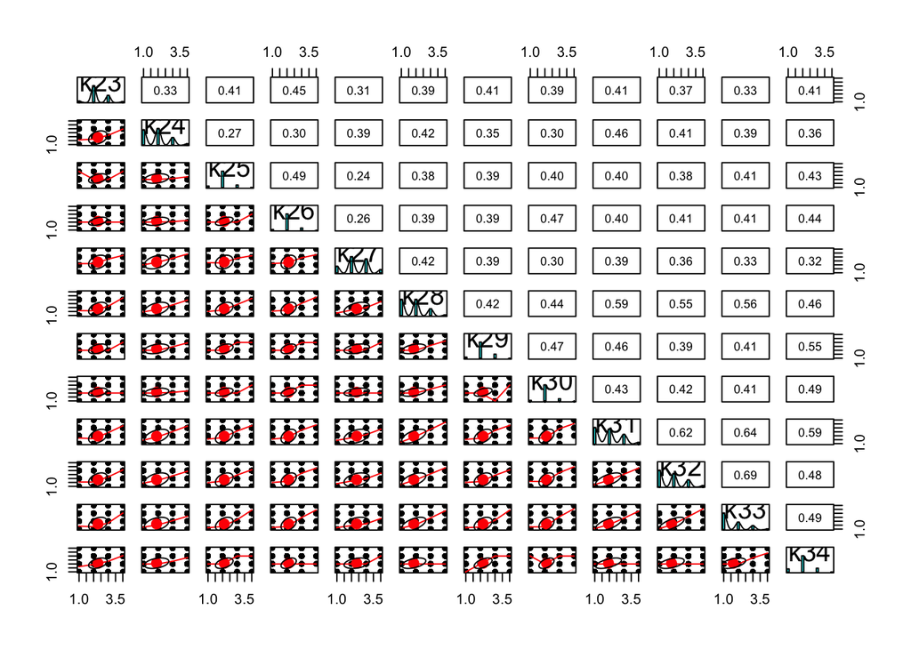

```r
?describe
pairs.panels(USHSghq)
```

```r
lowerCor(USHSghq)
```

```
##     k23  k24  k25  k26  k27  k28  k29  k30  k31  k32  k33
## k23 1.00
## k24 0.33 1.00
## k25 0.41 0.27 1.00
## k26 0.45 0.30 0.49 1.00
## k27 0.31 0.39 0.24 0.26 1.00
## k28 0.39 0.42 0.38 0.39 0.42 1.00
## k29 0.41 0.35 0.39 0.39 0.39 0.42 1.00
## k30 0.39 0.30 0.40 0.47 0.30 0.44 0.47 1.00
## k31 0.41 0.46 0.40 0.40 0.39 0.59 0.46 0.43 1.00
## k32 0.37 0.41 0.38 0.41 0.36 0.55 0.39 0.42 0.62 1.00
## k33 0.33 0.39 0.41 0.41 0.33 0.56 0.41 0.41 0.64 0.69 1.00
## k34 0.41 0.36 0.43 0.44 0.32 0.46 0.55 0.49 0.59 0.48 0.49
## [1] 1.00
```

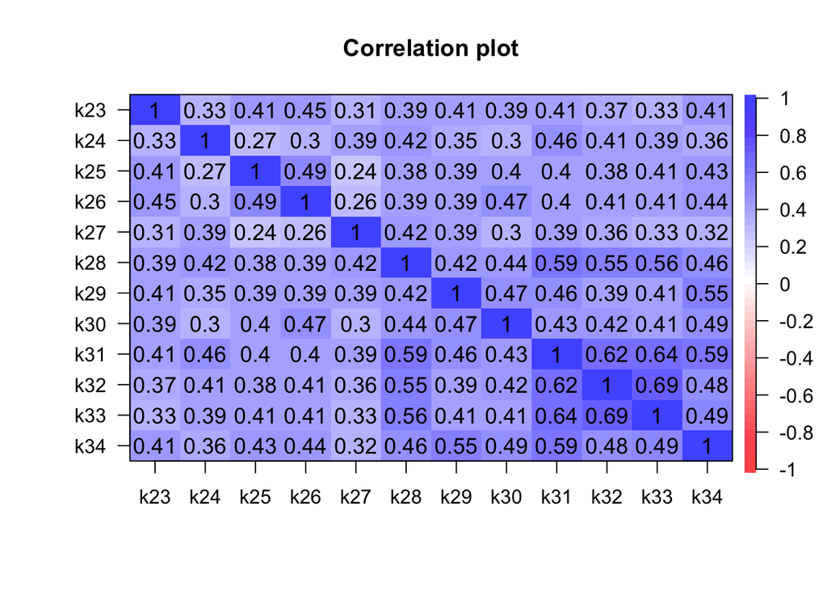

```r
cor.plot(USHSghq)
```

# Scree plot (estimating the number of factors)

Usually, if we know at least something about the substantial theory behind the phenomenon, we have at least a good initial estimate (often a final one, too) for the number of factors, which is a crucial parameter in FA.

However, now we do not know too much about the phenomenon and its dimensions. So, one way is to look at so called Scree plot (it comes also from the psych package):

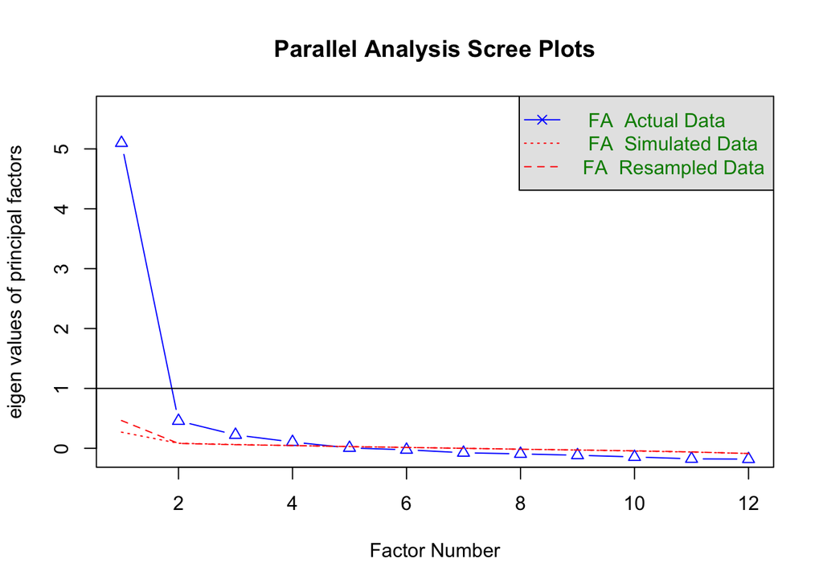

```
## Parallel analysis suggests that the number of factors =  4  and the number of components =  NA
```

```r
library(psych)
?fa.parallel
# Scree plot ("How many factors there could be?")
fa.parallel(USHSghq, fa = "fa", fm = "ml")
```

Here, the right number of factors seems to be something between 1 and 4. (Remember: we want to reduce the data - originally we have 12 variables.)

# Factor analysis, two factors

Let us begin with **TWO FACTORS** (that is quite typical also in practice).

In passing, we will consider two different rotation methods, one orthogonal (“varimax”), one oblique (“oblimin”). There are others, too, but they are out of the scope of this course. These two are well enough.

The general aim of the rotation is to find a **Simple Structure**, that would help to interpret the result: for each original variable, we hope to find a *high loading (correlation) for one factor*, and low loadings (correlations) for other factors.

It does not always go like that, as there might be **cross-loadings**: some variables that have correlations with several factors (thus making it more difficult to interpret).

One more package is needed here for the factor rotations. Install it, too! NOTE: we have two options for the factor rotation: a) orthogonal, and b) oblique.

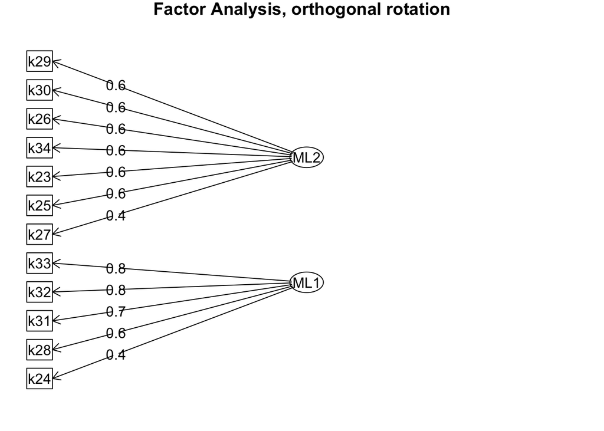

```r
library(GPArotation) # install.packages("GPArotation")

# a) orthogonal rotation (i.e., factors will not correlate with each other):
fa2a  <-  fa(USHSghq, nfactors = 2, rotate = "varimax", fm = "ml", scores = "regression")
# Draw a diagram of the factor model (measurement model):
fa.diagram(fa2a, cut = 0, main = "Factor Analysis, orthogonal rotation")
```

```r
# In the numerical output, focus on the factor loadings (columns ML1 and ML2).
# They are the correlations between the factors and the original variables:
# OBS: click "Show in New Window" to see all lines or Knit to a web page!
print(fa2a, digits = 2, sort = F) # 2 digits is enough for correlations, and sorting is useful
```

```
## Factor Analysis using method =  ml
## Call: fa(r = USHSghq, nfactors = 2, rotate = "varimax", scores = "regression",
##     fm = "ml")
## Standardized loadings (pattern matrix) based upon correlation matrix
##      ML2  ML1   h2   u2 com
## k23 0.58 0.24 0.39 0.61 1.3
## k24 0.35 0.41 0.30 0.70 2.0
## k25 0.55 0.28 0.38 0.62 1.5
## k26 0.60 0.27 0.43 0.57 1.4
## k27 0.36 0.34 0.25 0.75 2.0
## k28 0.42 0.58 0.51 0.49 1.8
## k29 0.61 0.30 0.46 0.54 1.4
## k30 0.60 0.30 0.45 0.55 1.5
## k31 0.42 0.67 0.63 0.37 1.7
## k32 0.30 0.75 0.65 0.35 1.3
## k33 0.29 0.77 0.68 0.32 1.3
## k34 0.59 0.42 0.53 0.47 1.8
##
##                        ML2  ML1
## SS loadings           2.87 2.80
## Proportion Var        0.24 0.23
## Cumulative Var        0.24 0.47
## Proportion Explained  0.51 0.49
## Cumulative Proportion 0.51 1.00
##
## Mean item complexity =  1.6
## Test of the hypothesis that 2 factors are sufficient.
##
## The degrees of freedom for the null model are  66  and the objective function was  5.02 with Chi Square of  15570.3
## The degrees of freedom for the model are 43  and the objective function was  0.22
##
## The root mean square of the residuals (RMSR) is  0.03
## The df corrected root mean square of the residuals is  0.04
##
## The harmonic number of observations is  3082 with the empirical chi square  463.77  with prob <  6e-72
## The total number of observations was  3110  with Likelihood Chi Square =  679.34  with prob <  2.3e-115
##
## Tucker Lewis Index of factoring reliability =  0.937
## RMSEA index =  0.069  and the 90 % confidence intervals are  0.064 0.074
## BIC =  333.51
## Fit based upon off diagonal values = 0.99
## Measures of factor score adequacy
##                                                    ML2  ML1
## Correlation of (regression) scores with factors   0.84 0.87
## Multiple R square of scores with factors          0.70 0.76
## Minimum correlation of possible factor scores     0.41 0.51
```

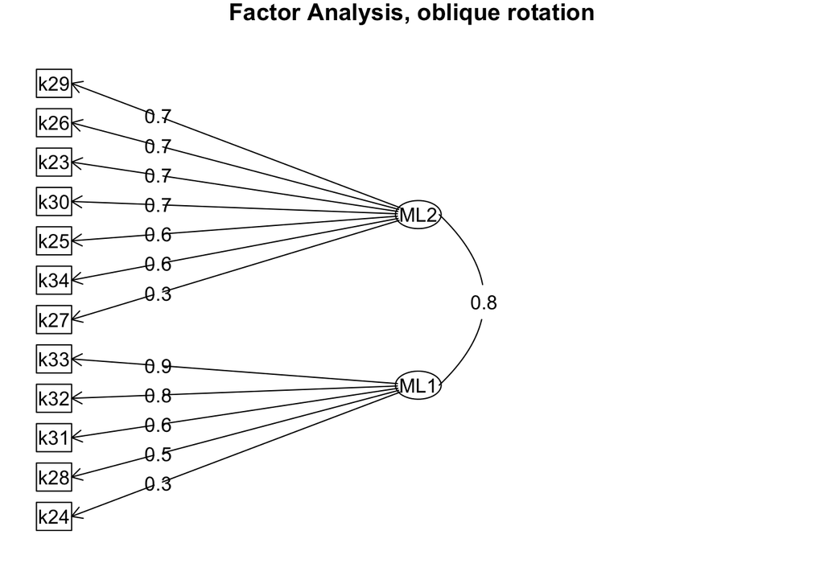

```r
# b) oblique rotation: (i.e., factors may correlate with each other):
fa2b  <-  fa(USHSghq, nfactors = 2, rotate = "oblimin", fm = "ml", scores = "regression")
# Draw a diagram of the factor model (measurement model):
fa.diagram(fa2b, cut = 0, main = "Factor Analysis, oblique rotation")
```

```r
# again, focus on the factor loadings: (and see OBS above)
print(fa2b, digits = 2, sort = TRUE)
```

```
## Factor Analysis using method =  ml
## Call: fa(r = USHSghq, nfactors = 2, rotate = "oblimin", scores = "regression",
##     fm = "ml")
## Standardized loadings (pattern matrix) based upon correlation matrix
##     item   ML2   ML1   h2   u2 com
## k29    7  0.68  0.00 0.46 0.54 1.0
## k26    4  0.67 -0.02 0.43 0.57 1.0
## k23    1  0.67 -0.05 0.39 0.61 1.0
## k30    8  0.66  0.01 0.45 0.55 1.0
## k25    3  0.60  0.02 0.38 0.62 1.0
## k34   12  0.58  0.19 0.53 0.47 1.2
## k27    5  0.30  0.23 0.25 0.75 1.9
## k33   11 -0.06  0.87 0.68 0.32 1.0
## k32   10 -0.03  0.83 0.65 0.35 1.0
## k31    9  0.19  0.65 0.63 0.37 1.2
## k28    6  0.24  0.52 0.51 0.49 1.4
## k24    2  0.24  0.34 0.30 0.70 1.8
##
##                        ML2  ML1
## SS loadings           3.03 2.64
## Proportion Var        0.25 0.22
## Cumulative Var        0.25 0.47
## Proportion Explained  0.53 0.47
## Cumulative Proportion 0.53 1.00
##
##  With factor correlations of
##      ML2  ML1
## ML2 1.00 0.75
## ML1 0.75 1.00
##
## Mean item complexity =  1.2
## Test of the hypothesis that 2 factors are sufficient.
##
## The degrees of freedom for the null model are  66  and the objective function was  5.02 with Chi Square of  15570.3
## The degrees of freedom for the model are 43  and the objective function was  0.22
##
## The root mean square of the residuals (RMSR) is  0.03
## The df corrected root mean square of the residuals is  0.04
##
## The harmonic number of observations is  3082 with the empirical chi square  463.77  with prob <  6e-72
## The total number of observations was  3110  with Likelihood Chi Square =  679.34  with prob <  2.3e-115
##
## Tucker Lewis Index of factoring reliability =  0.937
## RMSEA index =  0.069  and the 90 % confidence intervals are  0.064 0.074
## BIC =  333.51
## Fit based upon off diagonal values = 0.99
## Measures of factor score adequacy
##                                                    ML2  ML1
## Correlation of (regression) scores with factors   0.93 0.94
## Multiple R square of scores with factors          0.86 0.88
## Minimum correlation of possible factor scores     0.72 0.77
```

Study the factor loadings and the factor model diagrams in the two rotated factor solutions, a) and b). **What kind of differences can you see?**

Also pay some attention to the *communalities* (heading ‘h2’ in the output) of the variables: they are between 0 and 1; closer to 1 is a sign that the variable works better (less measurement errors and other random variation), while closer to 0 means that they do not have so much weight in the factor solution and interpretation. **Which variables have the highest communalities?**

Look at the factor loadings in detail. Which of the original variables correlate mostly with the factors? **Could you interpret the factors? (see the questionnaire or codebook!)** Could you give the factors some (brief) names? Which result (a or b) is easier to interpret, what do you think?

**AT THIS STAGE, WE ARE ALMOST THERE… :)**

# Let us review the steps taken so far! What does it require to do FA?

First, preparing the data and the variables:

1. Take a subset of the data, selecting a suitable set of variables for FA
   - remember: variables for FA must be numerical measurements (not categorical)
   - typical 1-5 scales are OK for FA (assuming that they represent some continuum from a negative to positive, e.g., from disagree to agree - “Likert scales”)
2. Compute some univariate statistics and (bivariate) correlations
   - you may also do some visualisations, of course (corrplot is good!)

Then, proceeding towards the Factor Analysis:

3. Draw a scree plot (for estimating the number of factors)
   - if you have substantial theory that states the dimensions of the phenomenon, trust that and you will know the right number without a scree plot
4. **The actual Factor Analysis**
   - often good to start with a **2 factor solution**
   - perhaps also check how a **3 factor solution** would look like (*)
   - consider the different rotations (orthogonal or oblique?)
   - try HARD to interpret some of the solutions and name the factors!

(*) Note: if you have more than two factors, there will be also more work below: each distribution and each pair of scatter plots: “1 vs 2”, “1 vs 3”, “2 vs 3” (in 3 factor case) etc. The pairs.panels() function could be useful.

**MOST OF THE TIME WILL BE SPENT IN STEP 4.**

The final step will be quite easy if you succeed well in the steps 1-4:

5. Reduce data based on FA, by working with the factor scores
   - compute the factor scores based on the selected, interpreted solution
   - rename the factor scores with more describing names, add fsd_id
   - copy the factor scores back in the original data
   - visualise the distributions of the factor scores
   - study the factor scores with background or/and other variables

So, let us proceed further, towards the end!

# Working with the factor scores

Hopefully you could give some names and interpretations for the factors, either in the case a) or b).

Finally, it would be time to work with the **factor scores**, that is, the predicted values of each of the factor for each respondent in the data (these will be positive and negative numbers that have an average about zero). For interpreting the directions (negative/positive), see the factor loadings and the scales of the original variables.

(The factor scores were already computed with the `scores = "regression"` option above, so no worries!)

After this phase, we can continue the data analysis using the new factor score variables and forget about the original variables. **That’s data reduction in action!**

```r
# Save the factor scores (based on two factors) to a new data set,
# and add the fsd_id variable from the original data (USHSv2).
#
# I am using the oblique solution (b), but you may as well use the orthogonal solution a),
# if you found an interpretation for that (in that case, change fa2b to fa2a below):

# Also rename the factor scores here. DO YOU HAVE BETTER NAMES FOR THEM?
# I hope so, as these ones are quite complicated and technical... on purpose) :)

library(tidyverse)
scores  <-  as.data.frame(factor.scores(USHSghq, fa2b)$scores)  %>%
  mutate(fsd_id = USHSv2$fsd_id)  %>%
  rename(NewName4GHQfscore1 = ML1,
         NewName4GHQfscore2 = ML2)

View(scores) # look at the result (fsd_id and the new factor scores)
```

By the way: as you can see from the scores data, if any of the original variables have missing values (NA), the result (factor score) is also missing (NA).

**Now, let us copy the renamed factor scores from the data ‘scores’ to our original data:**

```r
library(tidyverse)
USHSv2  <-  left_join(USHSv2, scores)
```

# Visualising the factor scores:

Let us see how the distributions of the factor scores look like. Also create their scatter plot.

Update the names of the factor scores here, according to your own choices above. (I hope you use shorter names!)

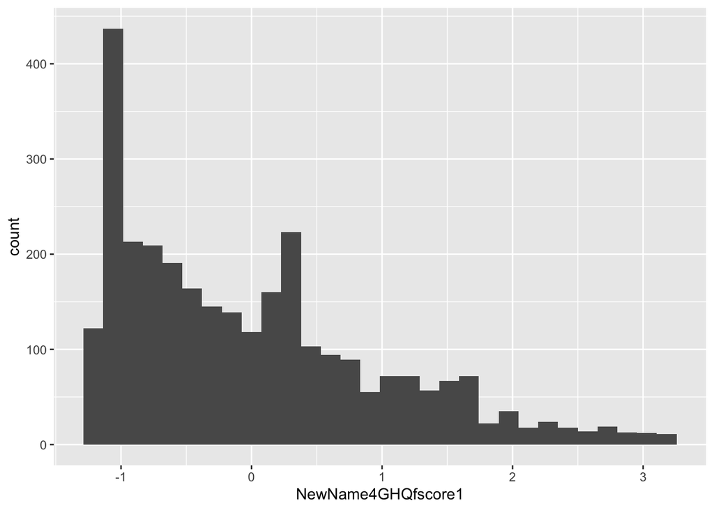

```r
library(tidyverse)
USHSv2  %>%
  ggplot(aes(x = NewName4GHQfscore1)) +
  geom_histogram()
```

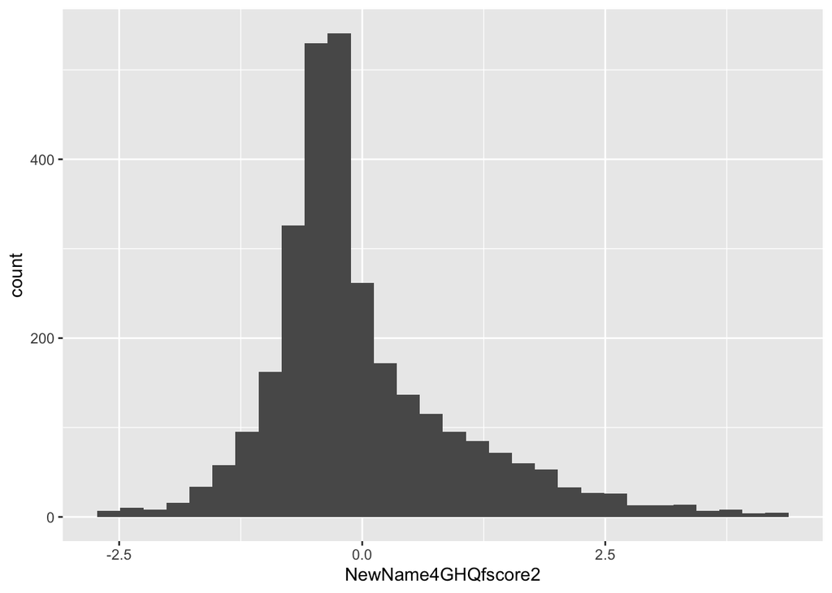

```r
USHSv2  %>%
  ggplot(aes(x = NewName4GHQfscore2)) +
  geom_histogram()
```

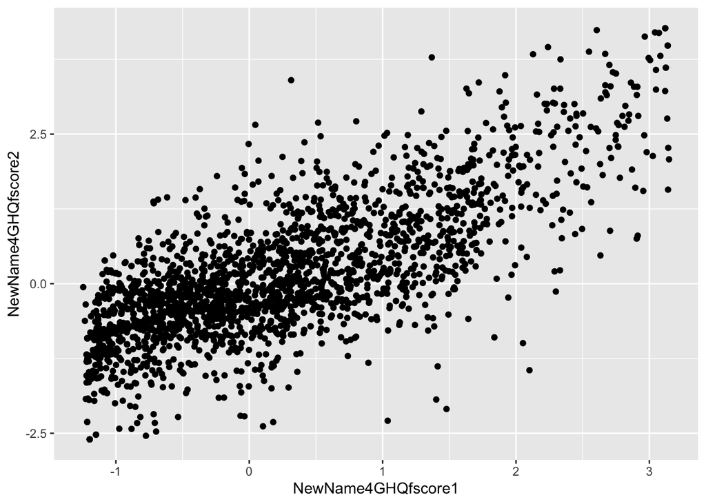

```r
USHSv2  %>%
  ggplot(aes(x = NewName4GHQfscore1, y = NewName4GHQfscore2)) +
  geom_point()
```

```r
# try adding some colours based on some other variables etc.!
# (see the earlier exercises on how to do that in ggplot)

# age and gender are already available - but how about some other (categorical) variables
# (box plots might be interesting, too!)
```

You have now completed the **Hands-On Exercise 2**. *GOOD JOB!*

That makes you ready for **Assignment 2**. Open it, complete it, knit it to HTML format and submit the result (HTML file) in Moodle. **You can do it!**